# Tutoriel d'introduction à Python

- Python a été lancé en 1991, il est actuellement dans le top 5 des langages de programmation (https://www.tiobe.com/tiobe-index/)
- langage interprété, orienté objet
- exécution de script (`python mon_script.py`) ou mode interactif (`ipython` ou `jupyter notebook` pour une interface web)
- installation avec le système ou en local avec un ensemble de librairies (https://anaconda.org)
- nombreuses librairies scientifiques (`numpy`, `scipy`, `matplotlib`) et dédiées à l'analyse des données et au machine learning (`pandas`, `scikit-learn`, `pytorch`)
- documentation sur le site de Python (https://docs.python.org/) et le tutoriel d'introduction (https://docs.python.org/3/tutorial/introduction.html)
- nombreuses ressources en ligne pour apprendre le langage par exemple http://learnpython.org/ et [Think Python](http://greenteapress.com/wp/think-python-2e/)
- la page Wikipedia donne une synthèse de l'histoire du langage https://fr.wikipedia.org/wiki/Python_(langage)
- pas mal d'évolutions et incompatibilités entre les versions 2 et 3

## Syntaxe

- syntaxe simple mais un peu différente du C/C++/C#/Java
- `#` avant les commentaires
- pas de séparateur d'instructions en fin de ligne (sinon `;`)
- indentation des blocs par le nombre d'espaces (pas d'accolades) - **attention à ne pas mélanger tabulations et espaces!**
- en cas de doute: `help(a)` ou simplement `a?` en interactif

### Types

- typage dynamique et implicite
- nombres, chaînes de caractères, listes, dictionnaires...
- objets

#### Nombres entiers, réels, complexes, booléens

- type `int` en précision illimitée
- type `float` équivalent à la double précision du C

```python
a = 3 * 5
b = 3.7
a + b
```

```
18.7
```

```python
type(3 + 4j)
```

```
complex
```

```python
a > b or False
```

```
True
```

#### Chaînes de caractères

Représentation interne en Unicode, délimiteur indifférement `'` ou `"`

```python
c = "une chaine" + " de caractères"
c
```

```
'une chaine de caractères'
```

```python
len(c)
```

```
24
```

Pas de conversion automatique entre nombres et chaînes de caractères

```python
int("3") + 5
```

```
8
```

```python
"3" + str(5)
```

```
'35'
```

Duplication de chaînes

```python
"3" * 5
```

```
'33333'
```

Nombreuses fonctions de manipulations de chaînes de caractères (syntaxe de méthodes objets)

```python
"abc123".upper()
```

```
'ABC123'
```

#### Listes

Les listes sont des tableaux indexés (commençant à 0)

```python
lst = ["pomme", "poire", a, b]
lst[0] += " golden"
lst
```

```
['pomme golden', 'poire', 15, 3.7]
```

Les indices négatifs se décomptent de la fin (-1 pour le dernier)

```python
lst[-1]
```

```
3.7
```

```python
len(lst)
```

```
4
```

Extraction de sous-listes (jusqu'au dernier indice exclu)

```python
lst[1:3]
```

```
['poire', 15]
```

Utilisation de liste comme pile/file

```python
file = ["pique", "coeur", "trèfle"]
file.append("carreau")
file
```

```
['pique', 'coeur', 'trèfle', 'carreau']
```

```python
file.pop(0)
```

```
'pique'
```

Tri de tableau

```python
sorted(["c", "a", "b"])
```

```
['a', 'b', 'c']
```

Les chaînes de caractères sont aussi des listes de caractères (si l'indice final n'est pas indiqué, va jusqu'à la fin)

```python
c[14:]
```

```
'caractères'
```

Pour tester la présence d'un élément dans un tableau (ou d'une sous-chaîne dans une chaîne)

```python
"coeur" in ["pique", "coeur", "trèfle"]
```

```
True
```

#### Dictionnaires

```python
cap = {"France": "Paris", "Italie": "Rome", "Allemagne": "Berlin"}
cap["Italie"]
```

```
'Rome'
```

#### Ensembles

```python
s = {4, 6, 2, 8}
s.intersection({3, 4, 5, 6, 7})
```

```
{4, 6}
```

### Structures de contrôle

- itérations

```python
# itération while
i = 1
while i < 5:
    print(i)
    i += 1
```

```
1
2
3
4
```

- énumération des valeurs d'une liste (ou plus généralement d'un itérable)

```python
for i in range(3):
    print(i)
```

```
0
1
2
```

```python
lst = ["pomme", "poire", 15, 3.7]
for i in lst:
    print(i)
```

```
pomme
poire
15
3.7
```

Il est possible d'itérer sur plusieurs indices simultanément, par exemple sur les couples clef/valeur d'un dictionnaire

```python
cap = {"France": "Paris", "Italie": "Rome", "Allemagne": "Berlin"}
for pays, ville in cap.items():
    print(pays, ville)
```

```
France Paris
Italie Rome
Allemagne Berlin
```

- Tests

```python
x = 3
if x < 0:
    print("négatif")
elif x == 0:
    print("nul")
else:
    print("positif")
```

```
positif
```

ou en mode compact (mais c'est moins lisible)

```python
"négatif" if x < 0 else "positif ou nul"
```

```
'positif ou nul'
```

- Fonctions

```python
def carre(a):
    return a * a


carre(4)
```

```
16
```

- Exceptions

```python
for i in [2, 1, 0]:
    try:
        print(1 / i)
    except ZeroDivisionError:
        print("pas d'inverse")
```

```
0.5
1.0
pas d'inverse
```

### Divers

- pas d'opérateurs d'incrément ('`++`'), utiliser '`+=1`' à la place
- opérateurs booléens '`and`', '`or`', '`not`' (différent du C)
- division réelle '`/`' et division entière '`//`' (Python 3)

```python
[3 / 2, 3 // 2, 5.0 // 1.5]
```

```
[1.5, 1, 3.0]
```

- affectations multiples

```python
x, y, z = [3, 2, 1]  # les crochets sont ici optionnels
```

- Compréhensions de listes, par exemple pour générer la listes des carrés des nombres pairs de 0 à 9 :

```python
[a ** 2 for a in range(10) if a % 2 == 0]
```

```
[0, 4, 16, 36, 64]
```

### Modules

Certaines fonctions nécessitent l'importation d'un module

```python
import math

math.cos(math.pi / 4)
```

```
0.7071067811865476
```

```python
import random

random.random()
```

```
0.7954862176168701
```

```python
help(random.random)
```

```
Help on built-in function random:

random() method of random.Random instance
    random() -> x in the interval [0, 1).
```

### Scripts et modules personnels

- exécution d'un script :

  ```
    $ python myscript.py
  ```

- gestion des arguments en ligne de commande directement ou avec le module `argparse`

  ```
    import sys
    print(sys.argv)
  ```

- appel d'un module rangé dans un autre fichier `mylib.py`

  ```
    import mylib
    print(mylib.carre(4))
  ```

- si les modules ne sont pas dans le répertoire du script

  ```
    import sys
    sys.append(‘/dossier/contenant/votre/script’)
    import mylib
  ```

- exécution d'un module directement comme un script (par exemple pour des tests)

  ```
    if __name__ == '__main__':
        assert carre(4) == 16
        print('test de mylib OK')
  ```

### Entrées-sorties

- ouverture d'un fichier texte avec sélection de l'encodage

  ```
    file = open('fichier.txt', 'r', encoding='utf-8')
  ```

- lecture ligne à ligne

  ```
    for line in file:
        line = line.rstrip('\n\r')
        ...
    file.close()
  ```

- lecture en bloc de l'ensemble des lignes dans un tableau de chaînes de caractères

  ```
    lines = file.readlines()
  ```

- fermeture automatique du fichier en cas d'erreur

  ```
    with open('fichier.txt','r') as file:
        lines = file.readlines()
  ```

## Numpy

- librairie de calcul scientifique (vecteurs, matrices, algèbre linéaire...)
- sert d'interface avec des bibliothèques bas niveau (LAPACK, BLAS)
- installé avec Anaconda
- documentation https://docs.scipy.org/doc/numpy/user/

```python
import numpy as np

# permet d'utiliser le raccourci 'np' à la place de numpy
```

Pour créer un vecteur ou une matrice Numpy (appelé **array**), on peut lui fourrnir une (liste de) liste(s) de valeurs entières ou réelles. A la différence des listes Python, tous les éléments sont du même type.

```python
m = np.array([[1, 2, 3], [4, 5, 6]])
m
```

```
array([[1, 2, 3],
       [4, 5, 6]])
```

Dimensions d'une matrice

```python
m.shape
```

```
(2, 3)
```

nombre de colonnes

```python
m.shape[1]
```

```
3
```

valeur d'un élément

```python
m[0, 1]
```

```
2
```

ligne d'une matrice

```python
v = m[1]  # ou m[1,:]
v
```

```
array([4, 5, 6])
```

extraction d'une colonne de la matrice

```python
m[:, 1]
```

```
array([2, 5])
```

NB: quant on extrait une ligne ou une colonne d'une matrice, on passe de 2 à 1 dimension - la direction initiale (ligne ou colonne) est perdue. Si on veut garder les 2 dimensions, il faut faire une extraction avec intervalle de largeur 1

```python
m[:, 1:2]
```

```
array([[2],
       [5]])
```

Plus généralement, extraction d'une sous-matrice (l'indice final est toujours exclu)

```python
m[:, 1:3]  #   ou  m[:,(1,2)]
```

```
array([[2, 3],
       [5, 6]])
```

critère booléen appliqué à l'ensemble des éléments

```python
v != 5
```

```
array([ True, False,  True])
```

indexation suivant un critère booléen

```python
v[v != 5]
```

```
array([4, 6])
```

matrice de zéros

```python
np.zeros((2, 2))
```

```
array([[0., 0.],
       [0., 0.]])
```

vecteur de uns

```python
np.ones((5))
```

```
array([1., 1., 1., 1., 1.])
```

transposition

```python
m.T
```

```
array([[1, 4],
       [2, 5],
       [3, 6]])
```

aplatissement de la matrice

```python
m.flatten()
```

```
array([1, 2, 3, 4, 5, 6])
```

changement de taille

```python
n = np.array([7, 8, 9, 10, 11, 12]).reshape((2, 3))
n
```

```
array([[ 7,  8,  9],
       [10, 11, 12]])
```

addition d'un scalaire à chaque élément d'une matrice (idem pour multiplication division soustraction)

```python
m + 10
```

```
array([[11, 12, 13],
       [14, 15, 16]])
```

addition de deux matrices

```python
m + n
```

```
array([[ 8, 10, 12],
       [14, 16, 18]])
```

multiplication de matrices ELEMENT PAR ELEMENT

```python
m * n
```

```
array([[ 7, 16, 27],
       [40, 55, 72]])
```

produit matriciel avec l'opérateur '`@`' depuis Python 3.5

```python
m @ n.T  # ou m.matmul(n.T)
```

```
array([[ 50,  68],
       [122, 167]])
```

produit de matrice et de vecteur

```python
m @ v  # ou m.dot(l)
```

```
array([32, 77])
```

produit scalaire

```python
v @ v  # ou np.vdot(v,v)
```

```
77
```

```python
m.sum(axis=0)
```

```
array([5, 7, 9])
```

```python
m.sum(axis=1)
```

```
array([ 6, 15])
```

somme globale

```python
m.sum()
```

```
21
```

autres opérations min, max, somme, moyenne, écart-type...

```python
print(m.min(), m.max(), m.sum(), m.mean(), m.std())
```

```
1 6 21 3.5 1.707825127659933
```

```python
m.argmax()
```

```
5
```

Le "broadcasting" permet d'appliquer le même vecteur pour chaque ligne de la matrice, c'est **beaucoup plus efficace** que de faire une boucle en Python

```python
m + np.array([5, 4, 3])
```

```
array([[6, 6, 6],
       [9, 9, 9]])
```

### entrées-sorties de matrices

- lecture/écriture de matrices au format binaire `.npy` avec `np.load` / `np.save`
- lecture/écriture au format texte avec `np.loadtxt` / `np.savetxt`
- plus d'options pour la lecture de fichiers texte avec `pandas.read_csv`

## Graphiques avec Matplotlib

- très nombreuses possibilités graphiques
- documentation https://matplotlib.org/users/
- combiné avec Numpy, iPython et une interface graphique comme Spyder, offre un environnement complet à la Matlab
- graphique "en ligne" (notebook, ipython/spyder), en fenêtre séparée interactive ou dans un fichier (pdf, png)

```python
%matplotlib inline
import matplotlib.pyplot as plt
```

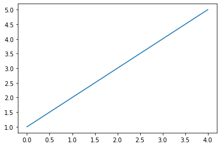

```python
plt.plot([1, 2, 3, 4, 5])
plt.show()
```

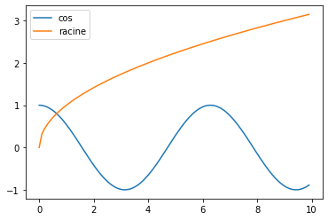

```python
x = np.arange(0, 10, 0.1)
y = np.cos(x)
plt.plot(x, np.cos(x), label="cos")
plt.plot(x, np.sqrt(x), label="racine")
plt.legend()
plt.show()
```

## Pour aller plus loin

- Notebooks d'Aurélien Géron sur [Numpy](https://github.com/ageron/handson-ml/blob/master/tools_numpy.ipynb) et [Matplotlib](https://github.com/ageron/handson-ml/blob/master/tools_matplotlib.ipynb)

C. Barras, Université Paris-Sud, 2018.  
This work is licensed under a [Creative Commons Attribution-NonCommercial-ShareAlike 4.0 International License](http://creativecommons.org/licenses/by-nc-sa/4.0/).